# My visual data story

A Data-Driven Look at Personal Gaming Patterns

## Devices Used During Long and Short Gaming Sessions

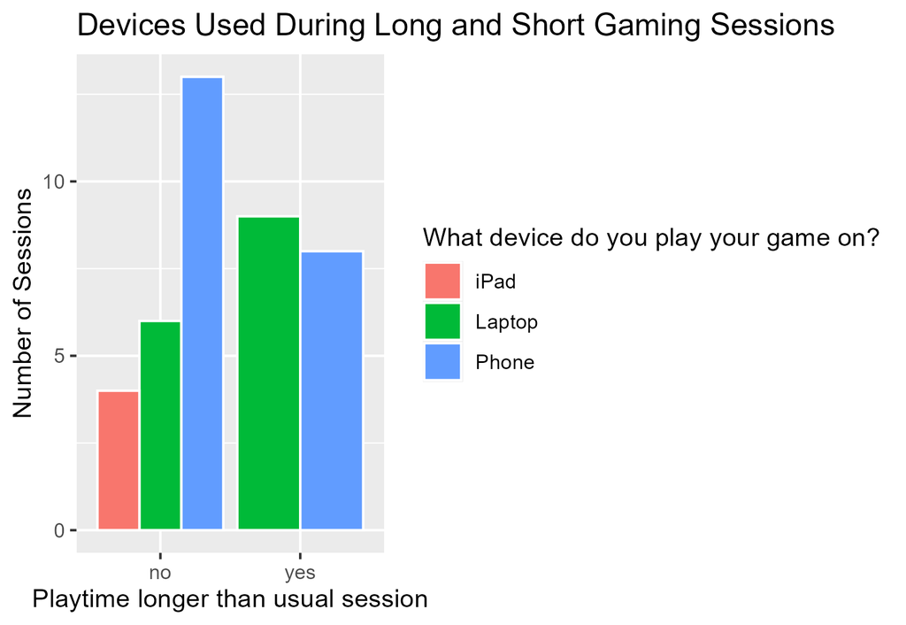

This graphic displays the devices I used throughout long and short gaming sessions (classified as long when the game time exceeds my average duration of 21 minutes).The data reveals I used to play longer on the laptop than on the phone and iPad, and that’s because, well, I normally only used the laptop when I got home, and occasionally while I played my favourite game, I forgot about the time….(laptop doesn’t display time when I enter full screen).

## What hour did i play the most game?

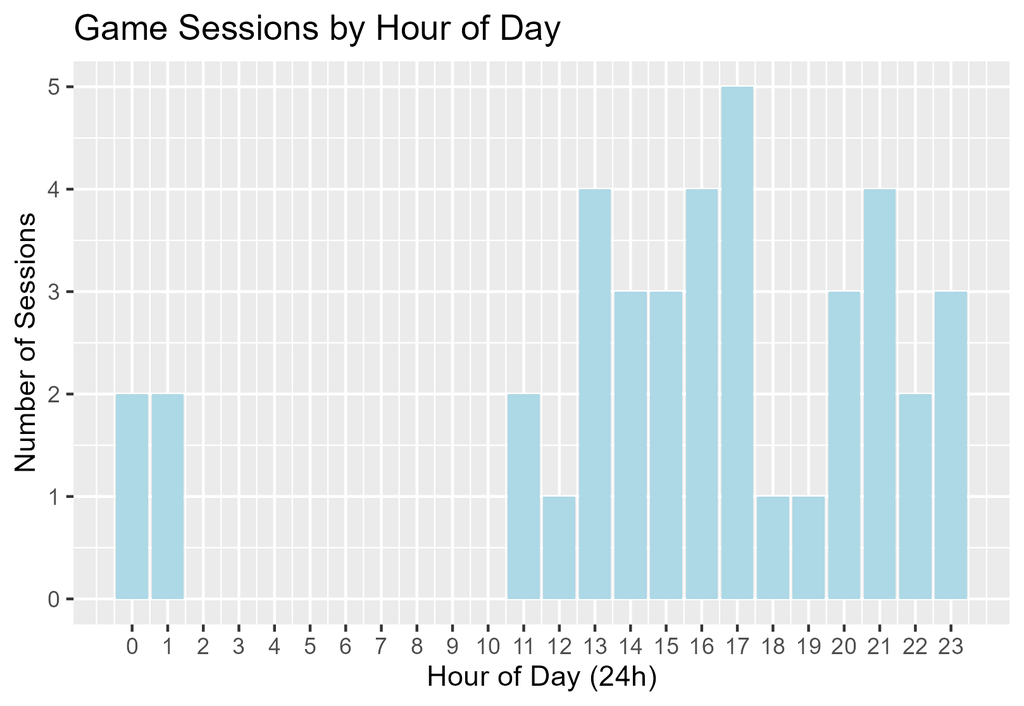

This chart shows when I am most active during the day. It helps in identifying peak gaming hours; for example, at 5 p.m., I’ve become obsessed with video games.

## Boredom Time Across Game Genres

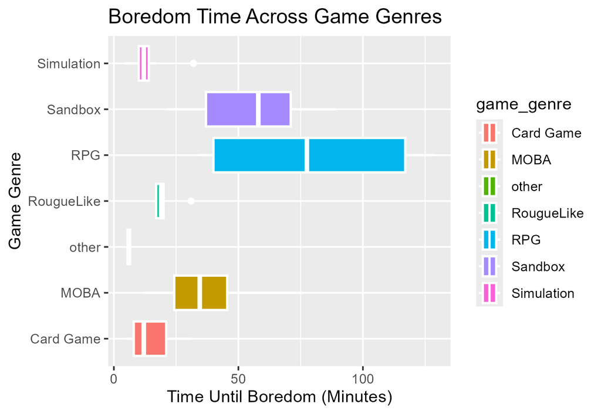

This graph helps to clarify how session duration varies by game genre. In this graph, we can see that RPGs often have the longest playtime, followed by Sandboxes; both game types have a long duration. Card games and other games have the shortest duration, as one round of card games usually only takes about 5 minutes (great for study breaks!)

## Top 5 Most Frequently Played Games (by Total Play Time)

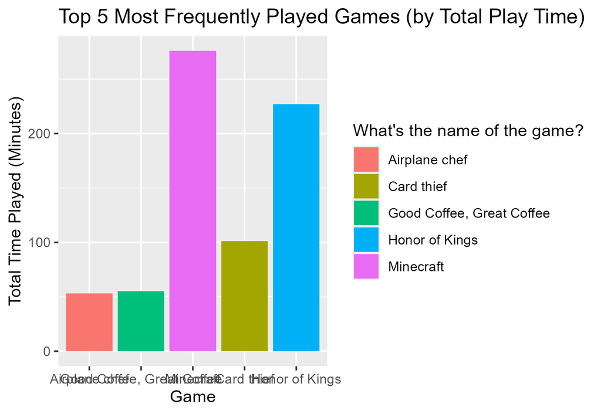